[figure not shown]

# Who We Are

The MIDI Manufacturers Association was official established as a California nonprofit, 501(c)6 trade organization) in 1985 with the goal to expand, promote, and protect MIDI technology for the benefit of artists and musicians around the world.  
In 2016, the MMA launched The MIDI Association, a public-facing, free, global, web-based community for people who create music and art with MIDI. Starting with no members at all, the MIDI Association now has over 38,000 registered individuals.  
In April 2020, the United States Library of Congress selected MIDI.org for inclusion in the historic collection of Internet materials related to the Professional Organizations for Performing Arts Web Archive. It’s an honor that they consider the MIDI website to be an important part of this collection and the historical record.  
The www.MIDI.org website is the central repository of information about all aspects of MIDI technology, from classic legacy gear to the next- gen protocols on the horizon.  
With the continued success (and growing recognition) of The MIDI Association, the MMA has decided to unify the two brands under the name The MIDI Association.  
The MIDI Manufacturers Association will remain the legal entity and there are no changes to the MMA bylaws, but the organization will do business as the MIDI Association.

# Individual and Corporate Memberships

The MIDI Association has two types of members

Corporate membership is open to any commercial entity that designs, develops, or produces products that use MIDI technology. This includes platform/OS developers like Apple, Google and Microsoft, and musical instrument and software companies (such as Ableton, Make Music, Mark Of The Unicorn, Native Instruments, Nektar, Roland, Roli, Steinberg, Yamaha, etc.).  
Corporate members develop and vote on new MIDI specifications, have access to proprietary software tools for MIDI 2.0 product development, can apply for logo licenses trademarked by the MIDI Association, and pay annual dues based on revenue.

Individual membership in the MIDI Association is free to musicians, artists, educators, retail salespeople, DIY/Arduino enthusiasts, DJs, game developers, and sound designers. MIDI Association individual members can download the adopted MIDI specifications, receive the MIDI Message newsletter, access MIDI Association tutorials and webinars and enjoy all the benefits of The MIDI Association, other than those that are exclusive to corporate members.  
MIDI has been connecting products and people for over 37 years, and the new MIDI 2.0 specification is once again poised to drive innovation in the music production industry—just as MIDI 1.0 did in 1984.

[figure not shown]

### Our Mission for Corporate Members

- To encourage the use of MIDI technology and MIDI products in established and growth markets.
- To be proactive in developing and enhancing MIDI to respond to market needs.
- To ensure interoperability of MIDI products through an open standards process with broad industry participation.
- To protect the meaning of the term MIDI as used in commerce

[Join the MIDI Association (Paid Corporate Membership)](https://midi.activehosted.com/f/26)

### MIDI Association Executive Board

Athan Billias (Yamaha) - President  
Pete Brown (Microsoft)  
Lawrence Levine (8EO)  
Brett Porter (Artiphon)  
Kate Stone (Novalia) - Exec Board Chair  
Jean-Baptiste Thiebaut (Music Hackspace) - Secretary  
Lee Whitmore (Focusrite) - Treasurer  
Yitian Zhao (CME)

[MIDI Association Anti-Trust Guidelines](https://www.midi.org/antitrust-guidelines)

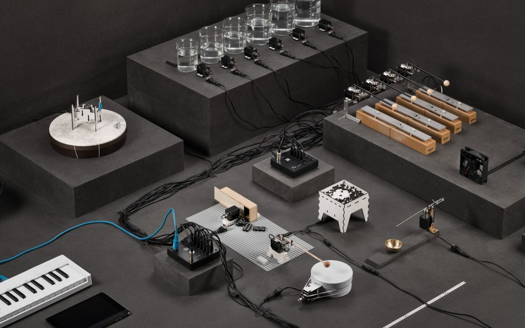

### Our Mission for Individual Members

- Nurture an inclusive community of people who create music and art with MIDI.
- Create an environment for community members to learn from each other.
- Explain new technical developments in MIDI and explore how to use them.
- Promote new ways of creatively using MIDI.
- Connect MIDI users with the companies that develop MIDI products.

[Join the MIDI Association. (Free Individual Membership)](https://www.midi.org/index.php?option=com_users&view=registration)

### MIDI Association Technical Standards Board

Geert Bevin (Moog Music) -MPE WG Chair  
Florian Bomers (Bome Software) - Transport WG Chair  
Rick Cohen (Antares) - TSB chair  
Chris Grigg (Chris Grigg Designs)  
Mike Kent (AmeNote) - MIDI 2.0 WG Chair  
Dave Starkey (MIDI9) - Piano Profile WG Chair  
Joe Zhang (Medeli)

[MIDI Association Intellectual Property Policy](https://www.midi.org/mma-ip-policy)

### Why Join As A Corporate Member?

With the adoption of MIDI 2.0, there are now many new benefits to joining the MIDI Association as a corporate member.

Membership is based on annual revenues and every MIDI Association corporate member has an equal vote in elections for the MIDI Association Executive Board and Technical Standards Board and on adoption of new MIDI Specifications.  
Here is a short list of new MIDI Association corporate member benefits:

- MIDI Association corporate membership gives you immediate access to new MIDI proposals under development and the MIDI Association Github repository that include a number of key MIDI 2.0 development tools including:
  - A MIDI 2.0 Compliance Work Sheet for determining which MIDI 2.0 features you support
  - MIDI 2.0 Scope -- an open source application (C++/JUCE) to aid in development/debugging of MIDI 2.0 channel voice message transmission and reception. Includes a permissively licensed JUCE User Module that implements the new protocol's messages.
  - MIDI-CI Work Bench- A Standalone Electron Application for a more complete MIDI 2.0 environment This workbench translates MIDI 1.0 (including MPE) to and from MIDI 2.0.
- After you develop a MIDI 2.0 product, MIDI Association corporate membership enables you to test for MIDI 2.0 compliance and apply to use the royalty free MIDI 2.0 logo on your product and packaging. The new MIDI 2.0 logo will give your customers confidence that your MIDI 2.0 products comply with the MIDI Association’s MIDI 2.0 specifications.
- MIDI Association corporate annual membership includes a SysEx ID (a $240 annual value). A valid unique MIDI SysEx ID is required to do manufacturer specific SysEx, Profiles and Property Exchanges. There are still lots of opportunities for new Profiles and new Property Exchange use cases and new protocol messages. It’s easier than ever to propose new ideas for MIDI.
- Marketing opportunities to participate in MIDI Association promotions like May Is MIDI Month and reach out directly to over 36,000 opted-in MIDI Association Members who work, play and create with MIDI and receive the monthly MIDI Message newsletter.

### You'll Be In Good Company!

The MIDI Association corporate members include innovative digital musical instrument technology companies including Apple, Microsoft, Korg, Roland, Yamaha, Ableton, Native Instruments, IK Multimedia, CME, Ringway, and Medeli. Member dues are based on annual revenue and range from $600-$20,000. A majority of MIDI Association corporate member companies are smaller innovative companies with annual revenues less than $1 million who pay $600 in annual dues. The MIDI Association is a member driven organization. Each company’s vote on adoption of MIDI standards and election of MIDI Association officers is equal so a brand-new MIDI start-up has the exact same voting power as some of the world’s largest companies who also participate as corporate MIDI Association members.  
We are excited about the future of MIDI 2.0 and we encourage you to become a part of the MIDI 2.0 revolution today.

MIDI Association Corporate Member Levels are based on annual revenue.

- $ 600-Annual Dues (sales under 1 Million $US/yr.)
- $ 1,200-Annual Dues (sales between 1 and 10 Million $US/yr.)
- $ 3,000-Annual Dues (sales between 10 and 100 Million $US/yr.)
- $ 4,000-Annual Dues (sales between 100 Million and 1 Billion $US/yr.)
- $ 8,000-Annual Dues (sales between 1 and 10 Billion $US/yr.)
- $ 12,000-Annual Dues (sales between 10 and 100 Billion $US/yr.)
- $20,000-Annual Dues (sales over 100 Billion $US/yr.)

[Join Now](https://midi.activehosted.com/f/26)

### Manufacturer System Exclusive IDs

The MIDI Association issues Manufacturer System Exclusive IDs to MIDI hardware and software producers world-wide (except Japan). These MIDI ID numbers allow developers to uniquely identify their products and provide a means for communicating product-specific information via MIDI protocol (using SysEx messages). The MIDI 1.0 Detailed Specification describes the format of SysEx messages, as well as all other MIDI messages that a developer may need to know to maintain industry compatibility.  
The MIDI Association procedures for the assignment of System Exclusive ID numbers are designed to prevent conflicts and incompatibilities. Each developer is assigned a unique number, which is annually renewable. These numbers are not transferable nor assignable without MMA approval.  
The MIDI Association publishes [a list of every assigned System Exclusive ID number.](https://midi.org/specifications-old/item/manufacturer-id-numbers) Companies that are known to be producing products using their ID may be listed on www.midi.org along with a link to their company web site. Companies that are not current with their ID Fee may have the ID suspended or revoked and will be noted as such on the website.

### MMA MEMBER ID Assignment

MMA Members will have their Annual SysEx ID Fee waived for as long as they are members. Technical assistance is available to MMA Members via an assigned Tech Board representative.

### NON-MEMBER ID Assignment

Companies that do not want to become MMA Members may obtain a SysEx ID by completing a **[New SysEX ID Form](https://midimanufacturersassociation.formstack.com/forms/sysex_id_new_app).** The applicant must pay the $240 Annual ID Fee and agree to continue to pay the then-current fee in each calendar year during which they produce any products that use the ID.

[Non Member SysEx ID form](https://midimanufacturersassociation.formstack.com/forms/sysex_id_new_app)

### MIDI 2.0 Specification Development

The MIDI Association is the official source of MIDI technology specifications. Compliance with MIDI Association Specifications and Recommended Practices enables thousands of products from hundreds of companies to interoperate. Companies wishing to take part in the development of new MIDI Specifications must be Corporate Members of the MIDI Association and abide by our confidentiality and IP policies. All Regular Members receive early access to new Specifications, can contribute to them, and can vote in MIDI Association corporate member elections.  
Note: As a general policy MMA does not disclose what is being addressed or discussed by our members until consensus has been reached. This policy is necessary because premature disclosure can create market confusion and reduce interoperability. However, some disclosure is necessary for manufacturers/developers to evaluate participating in MMA, so the following is an overview of the topics currently being discussed:  
Current Projects (2021):

- Multiple Profile Specifications
- Multiple Property Exchange Specifications
- USB-MIDI 2.0 Updates
- MIDI 2.0 for AVBTP/Time Sensitive Networks
- MIDI 2.0 over other transports
- Standard MIDI 2.0 File Specification

## The Official MIDI Specifications

The MIDI Manufacturers Association (MMA) produces the Specifications that make MIDI products work together. The Specifications define new MIDI Messages and new Recommended Practices for using MIDI Technology. Join the MIDI Association and use the links below to find and download all of the available MIDI Specifications and Recommended Practices.

[Read more](https://www.midi.org/specifications)

### Featured Video

Paul Prudence is an audio-visual performer who uses MIDI to create live-cinematic visual-music experiences.

### Recent Discussions

[figure not shown]

MIDI Software

They are referring to what the Standard MIDI Files Specification calls a "format." There are three formats of MIDI 1.0 files, numbered 0, 1 and 2.

[figure not shown]

MIDI Software